# Инструменты разработки

[figure not shown]

Кирилл Корняков (Intel, ННГУ)  
Февраль 2019

# Структура лекций

1. Первые 10 минут письменная самостоятельная работа
   - Рекомендуется посещать и не опаздывать
2. Основная часть, лекция
   - Рекомендуется вести конспект
3. Иногда постараемся проводить живые демонстрации

# Практические занятия

Необходимо разработать библиотеку на С++, которая:

1. Решает простую прикладную задачу
2. Разрабатывается на GitHub
3. Собирается при помощи CMake
4. Имеет модульные тесты на базе GoogleTest
5. Имеет документацию

Каждый шаг засчитывается в момент попадания вашего кода в [центральный репозиторий](https://github.com/UNN-VMK-Software/devtools-course).

# Порядок приема лабораторных работ

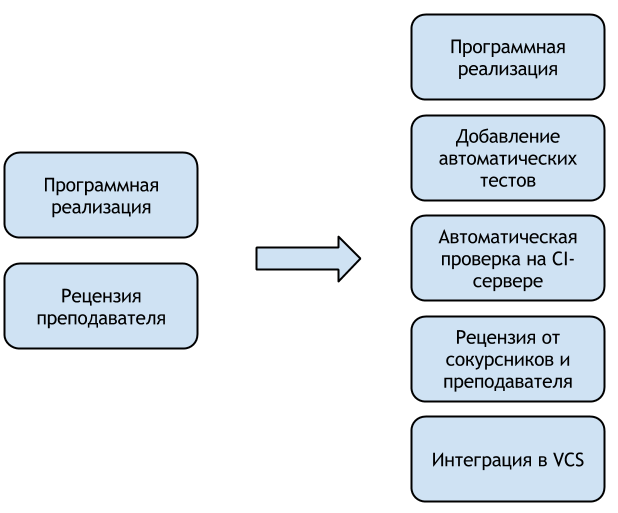

# Отчетность

- Наличие всех самостоятельных работ
- Наличие кода в **центральном** репозитории

# Ресурсы

- [Слайды](http://unn-vmk-software.github.io/devtools-course-theory/)

# Важность инструментов

Инструменты пока не могут создавать ПО вместо вас, однако

- Значительно усиливают ваши способности
- Работают пока вы спите

# Разнообразие технологий

Опыт типичного разработчика сегодня

- **Host OS**: Windows, Linux, macOS
- **Target OS**: Embedded Win/Lin, Android, iOS
- **Target HW**: x86, ARM, GPU, а также MIPS, DSP
- **Языки**:
  - Native: С, С++, Objective-C
  - Bytecode: C#, Java
  - Dynamic: Python, Ruby
  - GPU: GLSL, CUDA, OpenCL
- **IDE**: Borland Builder, MSVS, Eclipse, Qt Creator, Xcode

# Цели курса

> Познакомить с некоторыми **классами инструментов и подходами**,  
> которые будут полезны при работе **в любом проекте и на любой платформе**.

# Хороший инструмент

Мы постараемся сосредоточиться на "хороших" инструментах.  
И очень часто это будут консольные и веб-приложения.

1. Проверен временем (["Lindy effect"](https://en.wikipedia.org/wiki/Lindy_effect))
2. Кросс-платформенный
3. Допускает автоматизацию
4. Быстрый
5. Имеет открытый исходный код

# Программа курса: Жизненный цикл разработки ПО

**Waterfall Model** of the Software Development Lifecycle

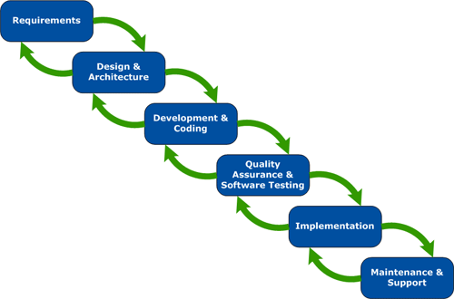

# Программа курса: От малого к большому

1. Личное мастерство
   - Работа с текстом
   - Автоматизация
2. Работа с кодом
   - Построение систем
   - Анализ бинарных модулей
3. Качество кода
   - Содержание кода "в чистоте"
   - Тестирование и отладка
4. Коллективная разработка
   - Коммуникация
   - Управление задачами
   - Формирование сообщества

# "Золотые" практики Программной Инженерии

- Автоматические тесты
- Непрерывная интеграция
- Рецензии кода (формальные инспекции)
- Использование VCS

# Development Workflow

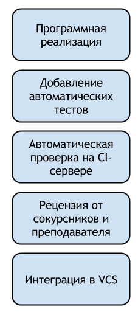

# Android Contribution Workflow

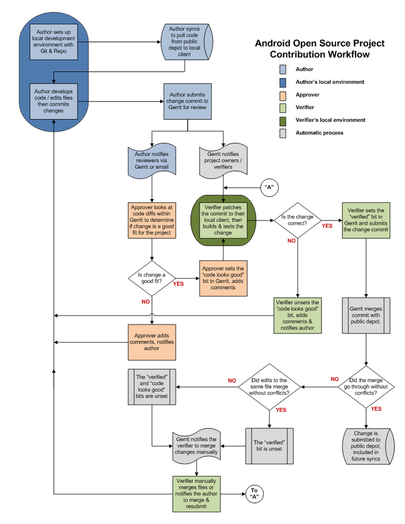

# OpenCV Workflow

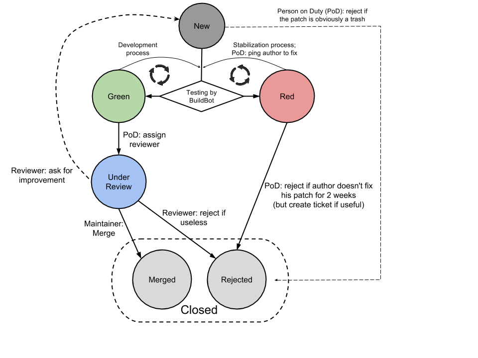

# Инструментальная поддержка

- Автоматические тесты
  - **Unit-testing frameworks** (xUnit: JUnit, Google Test, NUnit)
- Непрерывная интеграция (Continuous Integration)
  - **Continuous Integration systems** (Jenkins, BuildBot, Travis)
- Код ревью
  - Web-based **Code Review systems** (Review Board, GitHub)
- Использование VCS
  - **Distributed VCS** (Git, Mercurial)

Сегодня все эти классы инструментов достаточно зрелые, и доступны бесплатно.

# Современное состояние

- На сегодняшний день "лучшие" практики стали более легковесными,  
  и наконец сложились в некоторую "гармоничную" схему.
- Эту схему можно условно назвать *современным рабочим процессом* (workflow),  
  и она применяется во многих современных проектах (Android, Chrome, OpenCV).
- Данный workflow имеет ряд преимуществ:
  - *простота и легковесность*
  - *стабильность* — система всегда в рабочем состоянии
  - *высокое качество кода* — благодаря объединению тестирования и рецензирования
  - *предсказуемость* и *управляемость* процесса разработки

Одним словом, появилась возможность контролируемо развивать ПО,  
снижая влияние человеческого фактора.

# Базовые принципы

1. Предпочитайте plain-text формат в качестве исходного
   - Храните исходники в VCS
   - Овладейте техникой обработки текста в совершенстве
2. Освойте командную строку, используйте ее по максимуму
   - Обработка текста
   - Автоматизация рутинных операций
3. Изучите Python и его популярные модули
   - NumPy, Matplotlib
   - XML, Excel, pdf, email

# Базовые принципы (2)

1. В деталях изучите устройство бинарных модулей
   - Последовательность шагов построения приложений (компиляция и линковка)
   - Инструменты анализа готовых файлов
2. Разрабатывайте так, чтобы вам не приходилось заниматься отладкой
   - Непрерывная интеграция (автоматическое тестирование)
   - Контроль качества кода (автоматический анализ и peer review)
3. Переиспользуйте стороннее ПО, преимущественно open-source
   - Стремительное развитие проекта (Android)
   - Полная свобода настройки и переделки

# Книги

- Стив Макконнелл "Совершенный код"
- Дейв Томас, Энди Хант "Программист-прагматик"
- Нил Форд "Продуктивный программист"
- Kernighan & Pike "The Practice of Programming"

# Контрольные вопросы

1. Общее назначение инструментов, примеры.
2. Признаки "хороших" инструментов, с пояснениями.
3. Примеры практик Программной инженерии, их суть.
4. Приведите примеры инструментов, помогающих применять практики.
5. Диаграмма каскадной модели жизненного цикла.
6. Диаграмма работы программиста над задачей.

# Спасибо за внимание!

Вопросы?